# Chapter 3: Log-regression

Mikko Salonen

7 February 2017

# Chapter 3: Log-regression

### Preliminary actions

Let’s first read the data from a local folder and print out the column names. This file has data on student alcohol consumption, descriptive variables, and most importantly number of absences and final grade (G3 - from 0 to 20). We will analyse the relatinship between alcohol consumption (binary variable high_use) to other variables (G3 test grade, mothers education, gender, and absences). Hypothesis: i) from previous studies the mothers educational background usually has had a good explanatory strength in the performance/behavior of their children. Furthermore, ii) males tend to drink more, iii) and absences captures the “dropout” behavior in the data. iv) Low test performance likely affects (and other way as well) tendency to drink because students are, in lack of other words, demoralized or simply sad. v) Freetime and goout measure the reported ‘boredom’ or neglect of coursework as well as amount of socializing of the students.

```r
library(dplyr)
summarise(group_by(alc, high_use), testin_k_arvo = mean(G3), testin_hajonta = sd(G3))
```

```
## # A tibble: 2 × 3
##   high_use testin_k_arvo testin_hajonta
##      <lgl>         <dbl>          <dbl>
## 1    FALSE      11.73507       3.385467
## 2     TRUE      10.80702       3.042115
```

```r
tarkasteltavat_muuttujat <- c("high_use","G3","Medu","sex","absences","freetime","goout")
data <- select(alc, one_of(tarkasteltavat_muuttujat))
glimpse(data)
```

```
## Observations: 382
## Variables: 7
## $ high_use <lgl> FALSE, FALSE, TRUE, FALSE, FALSE, FALSE, FALSE, FALSE...
## $ G3       <int> 8, 8, 11, 14, 12, 14, 12, 10, 18, 14, 12, 12, 13, 12,...
## $ Medu     <int> 4, 1, 1, 4, 3, 4, 2, 4, 3, 3, 4, 2, 4, 4, 2, 4, 4, 3,...
## $ sex      <fctr> F, F, F, F, F, M, M, F, M, M, F, F, M, M, M, F, F, F...
## $ absences <int> 5, 3, 8, 1, 2, 8, 0, 4, 0, 0, 1, 2, 1, 1, 0, 5, 8, 3,...
## $ freetime <int> 3, 3, 3, 2, 3, 4, 4, 1, 2, 5, 3, 2, 3, 4, 5, 4, 2, 3,...
## $ goout    <int> 4, 3, 2, 2, 2, 2, 4, 4, 2, 1, 3, 2, 3, 3, 2, 4, 3, 2,...
```

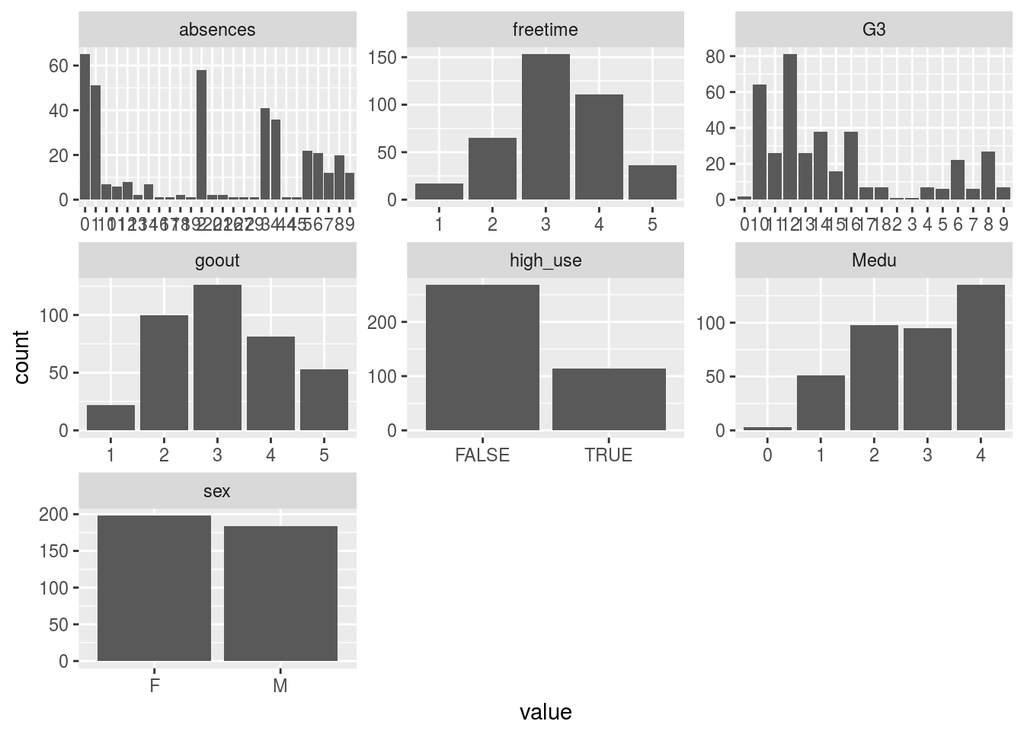

```r
library(ggplot2)
library(tidyr)
gather(data) %>% ggplot(aes(value)) + facet_wrap("key", scales = "free") +geom_bar()
```

Next we check the frequencies of high usage among different sexes and variables: grades (G3), absences, and Mothers education. We also plot boxplots to check the distribution among these subgroups.

```r
library(dplyr)
data %>% group_by(sex,high_use) %>% summarise(count = n(),mean_grade = mean(G3))
```

```
## Source: local data frame [4 x 4]
## Groups: sex [?]
##
##      sex high_use count mean_grade
##   <fctr>    <lgl> <int>      <dbl>
## 1      F    FALSE   156   11.39744
## 2      F     TRUE    42   11.71429
## 3      M    FALSE   112   12.20536
## 4      M     TRUE    72   10.27778
```

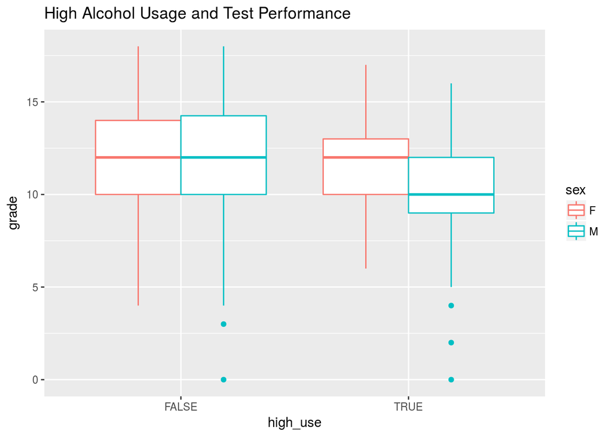

```r
ggplot(alc, aes(x = high_use, y = G3, col=sex)) + geom_boxplot() + ylab("grade") + ggtitle("High Alcohol Usage and Test Performance")
```

```r
data %>% group_by(sex,high_use) %>% summarise(count = n(), mean_absences = mean(absences))
```

```
## Source: local data frame [4 x 4]
## Groups: sex [?]
##
##      sex high_use count mean_absences
##   <fctr>    <lgl> <int>         <dbl>
## 1      F    FALSE   156      4.224359
## 2      F     TRUE    42      6.785714
## 3      M    FALSE   112      2.982143
## 4      M     TRUE    72      6.125000
```

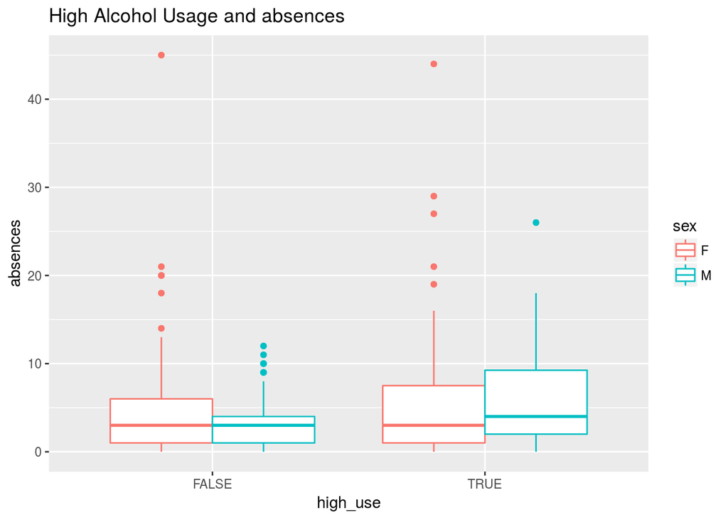

```r
ggplot(alc, aes(x = high_use, y = absences, col=sex)) + geom_boxplot() + ylab("absences") + ggtitle("High Alcohol Usage and absences")
```

```r
data %>% group_by(sex,high_use) %>% summarise(count = n(), mean_mothersEdu = mean(Medu))
```

```
## Source: local data frame [4 x 4]
## Groups: sex [?]
##
##      sex high_use count mean_mothersEdu
##   <fctr>    <lgl> <int>           <dbl>
## 1      F    FALSE   156        2.673077
## 2      F     TRUE    42        2.785714
## 3      M    FALSE   112        2.973214
## 4      M     TRUE    72        2.847222
```

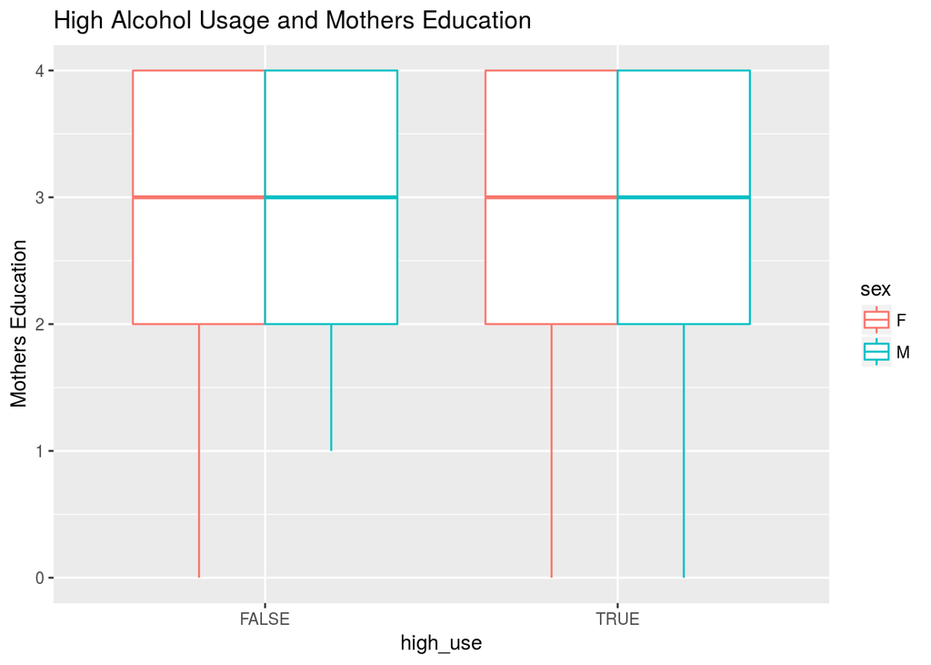

```r
ggplot(alc, aes(x = high_use, y = Medu, col=sex)) + geom_boxplot() + ylab("Mothers Education") + ggtitle("High Alcohol Usage and Mothers Education")
```

```r
data %>% group_by(sex,high_use) %>% summarise(count = n(), mean_freetime = mean(freetime))
```

```
## Source: local data frame [4 x 4]
## Groups: sex [?]
##
##      sex high_use count mean_freetime
##   <fctr>    <lgl> <int>         <dbl>
## 1      F    FALSE   156      2.929487
## 2      F     TRUE    42      3.357143
## 3      M    FALSE   112      3.392857
## 4      M     TRUE    72      3.500000
```

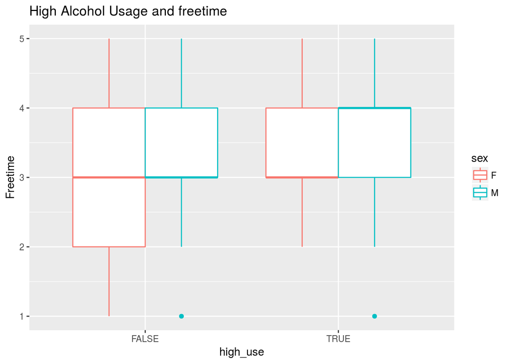

```r
  ggplot(alc, aes(x = high_use, y = freetime, col=sex)) + geom_boxplot() + ylab("Freetime") + ggtitle("High Alcohol Usage and freetime")
```

```r
  data %>% group_by(sex,high_use) %>% summarise(count = n(), mean_goout = mean(goout))
```

```
## Source: local data frame [4 x 4]
## Groups: sex [?]
##
##      sex high_use count mean_goout
##   <fctr>    <lgl> <int>      <dbl>
## 1      F    FALSE   156   2.955128
## 2      F     TRUE    42   3.357143
## 3      M    FALSE   112   2.714286
## 4      M     TRUE    72   3.930556
```

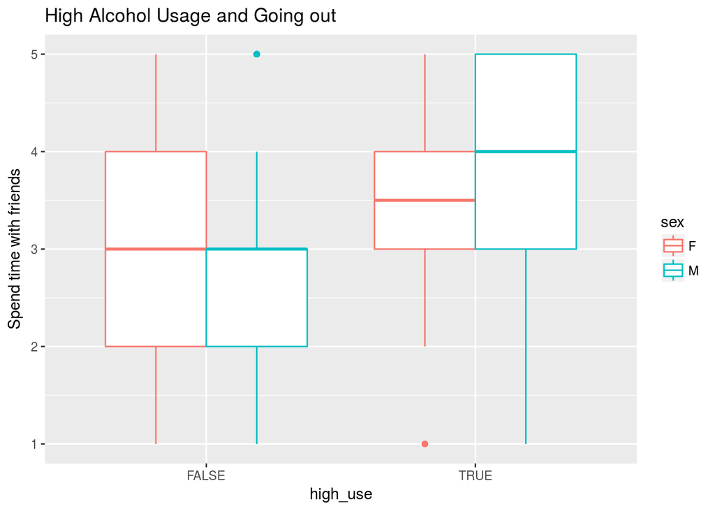

```r
  ggplot(alc, aes(x = high_use, y = goout, col=sex)) + geom_boxplot() + ylab("Spend time with friends") + ggtitle("High Alcohol Usage and Going out")
```

It appears that test performance is lowe especially for men for high users of alcohol. Similar effect can be found for absences; high users of acohol are more likely to miss classes, especially for men. We did not find a clear difference based on Mothers education (our initial hypothesis seems to have been wrong) and therefore change our attention to freetime. High users seem to have more freetime, this might be due to neglect of work or just plain boredom. Similarly, individuals which are more social or have less preference to study tend to be higher drinkers.

### The model

Next we fit a logistic model to explain high usage of alcohol. Our model is the following

> high_use ~ freetime + absences + sex + goout

```r
# find the model with glm()
m <- glm(high_use ~ freetime + absences + sex + goout, data = alc, family = "binomial")

# print out a summary of the model
summary(m)
```

```
##
## Call:
## glm(formula = high_use ~ freetime + absences + sex + goout, family = "binomial",
##     data = alc)
##
## Deviance Residuals:
##     Min       1Q   Median       3Q      Max
## -1.7938  -0.8060  -0.5306   0.8297   2.4887
##
## Coefficients:
##             Estimate Std. Error z value Pr(>|z|)
## (Intercept) -4.33104    0.57522  -7.529 5.10e-14 ***
## freetime     0.07254    0.13705   0.529 0.596610
## absences     0.08487    0.02240   3.789 0.000151 ***
## sexM         0.93806    0.25762   3.641 0.000271 ***
## goout        0.71094    0.12444   5.713 1.11e-08 ***
## ---
## Signif. codes:  0 '***' 0.001 '**' 0.01 '*' 0.05 '.' 0.1 ' ' 1
##
## (Dispersion parameter for binomial family taken to be 1)
##
##     Null deviance: 465.68  on 381  degrees of freedom
## Residual deviance: 387.47  on 377  degrees of freedom
## AIC: 397.47
##
## Number of Fisher Scoring iterations: 4
```

```r
# print out the coefficients of the model
coef(m)
```

```
## (Intercept)    freetime    absences        sexM       goout
## -4.33104146  0.07253827  0.08487446  0.93806336  0.71094375
```

```r
#ODDS ratio of 1/6, individual is 1/6 likely to succeed with X, the exponent of the coefficients: exp(beta) = odds(Y|x+1)/odds(Y|x)

# compute odds ratios (OR)
OR <- coef(m) %>% exp

# compute confidence intervals (CI)
CI <- confint(m) %>% exp
# print out the odds ratios with their confidence intervals
cbind(OR, CI)
```

```
##                     OR      2.5 %     97.5 %
## (Intercept) 0.01315384 0.00406496 0.03896248
## freetime    1.07523395 0.82191021 1.40863837
## absences    1.08858040 1.04303580 1.14007640
## sexM        2.55502845 1.55086699 4.26706152
## goout       2.03591174 1.60487130 2.61688539
```

When goout (spending time with friends) is included in the model it seems that freetime does not have explanatory power in the model. From the print above, one can see that amount of absences, gender, and social activity seem to explain alcohol usage quite well. For example, an individual answering that they spend more time with friends (Likert scale) are twice as likely to use high amounts of alcohol, everything else held constant. Likewise, males are much more likely to spend more alcohol and students who are absent have a small risk factor. Note that freetime is not signifficant at p-value 10% (or 5%) and the confidence interwal includes 1 for odds ratios, which means that the model suggest that there is no clear causality weather students whom spend more freetime have a higher or lower risk to consume high amounts of alchol. The results show that the initial hypothesis on social behaviour, gender, and amount absences seem to be correct but ones on Mothers education (based on the graph above) or freetime spent were not.

### Validation

Now we try to make predictions and cross-validation based on the model used.

```r
# find the model with glm()
m <- glm(high_use ~ freetime + absences + sex + goout, data = alc, family = "binomial")

# predict() the probability of high_use
probabilities <- predict(m, type = "response")

# add the predicted probabilities to 'alc'
alc <- mutate(alc, probability = probabilities)

# use the probabilities to make a prediction of high_use
alc <- mutate(alc, prediction = probability > 0.5)

# tabulate the target variable versus the predictions
table(high_use = alc$high_use, prediction = alc$prediction)
```

```
##         prediction
## high_use FALSE TRUE
##    FALSE   250   18
##    TRUE     64   50
```

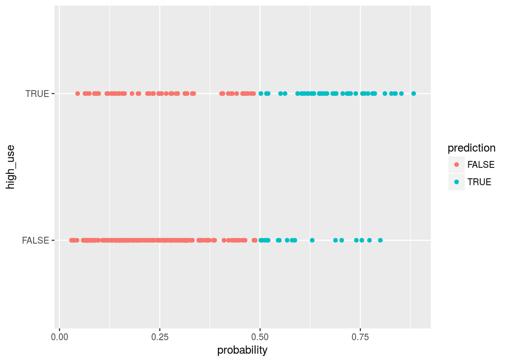

```r
# initialize a plot of 'high_use' versus 'probability' in 'alc'
g <- ggplot(alc, aes(x = probability, y = high_use, col=prediction))

# define the geom as points and draw the plot
g + geom_point()
```

```r
# tabulate the target variable versus the predictions
table(high_use = alc$high_use, prediction = alc$prediction) %>% prop.table %>% addmargins()
```

```
##         prediction
## high_use      FALSE       TRUE        Sum
##    FALSE 0.65445026 0.04712042 0.70157068
##    TRUE  0.16753927 0.13089005 0.29842932
##    Sum   0.82198953 0.17801047 1.00000000
```

```r
# define a loss function (mean prediction error)
loss_func <- function(class, prob) {
  n_wrong <- abs(class - prob) > 0.5
  mean(n_wrong)
}

# call loss_func to compute the average number of wrong predictions in the (training) data
loss_func(class = alc$high_use, prob = alc$probability)
```

```
## [1] 0.2146597
```

```r
# K-fold cross-validation
library(boot)
cv <- cv.glm(data = alc, cost = loss_func, glmfit = m, K = 10)

# average number of wrong predictions in the cross validation
cv$delta[1]
```

```
## [1] 0.2146597
```